# New York Yellow Cabs Data Analysis

Kimia Khaffafzadeh Ahrabi, Amir Nejat, Tarek Halabi

5/16/2020

Introduction:

The dataset we have worked on belongs to the yellow taxi cabs that operate in New York. We chose October 2018 data to analyze and try to see if we can learn more about the commute new yorkers experience on a daily basis.

We began by setting up and cleaning the data, only selecting our desired attributes. The mentioned dataset had 8 million entries so we took a random sample of 2 million entries to work with.

```r
url <- "https://s3.amazonaws.com/nyc-tlc/trip+data/yellow_tripdata_2018-10.csv"
taxi_tab <- read_csv(url)
head(taxi_tab)
```

```
## # A tibble: 6 x 17
##   VendorID tpep_pickup_dateti… tpep_dropoff_datet… passenger_count trip_distance
##      <dbl> <dttm>              <dttm>                        <dbl>         <dbl>
## 1        1 2018-10-01 00:23:34 2018-10-01 00:44:50               1           6.2
## 2        1 2018-10-01 00:40:05 2018-10-01 01:01:56               1          12.6
## 3        1 2018-10-01 00:05:35 2018-10-01 00:19:38               1           6.1
## 4        1 2018-10-01 00:42:56 2018-10-01 00:49:00               1           1.3
## 5        1 2018-10-01 00:19:14 2018-10-01 00:31:54               1           2.6
## 6        1 2018-10-01 00:36:27 2018-10-01 01:39:20               1          19.7
## # … with 12 more variables: RatecodeID <dbl>, store_and_fwd_flag <chr>,
## #   PULocationID <dbl>, DOLocationID <dbl>, payment_type <dbl>,
## #   fare_amount <dbl>, extra <dbl>, mta_tax <dbl>, tip_amount <dbl>,
## #   tolls_amount <dbl>, improvement_surcharge <dbl>, total_amount <dbl>
```

```r
taxi_tab <- taxi_tab %>%
  sample_n(2000000) %>%
  select(VendorID, tpep_pickup_datetime, tpep_dropoff_datetime, passenger_count, trip_distance, fare_amount, tip_amount, tolls_amount, PULocationID, DOLocationID)
head(taxi_tab)
```

[output not shown]

The data set includes the drop off and pickup location. However, it has used location identification number to specify different zones in New York. We found a helpful table mentioning which borough of New York these IDs refer to.

```r
zoneurl <- "https://s3.amazonaws.com/nyc-tlc/misc/taxi+_zone_lookup.csv"
zone_tab <- read_csv(zoneurl)
head(zone_tab)
```

```
## # A tibble: 6 x 4
##   LocationID Borough       Zone                    service_zone
##        <dbl> <chr>         <chr>                   <chr>
## 1          1 EWR           Newark Airport          EWR
## 2          2 Queens        Jamaica Bay             Boro Zone
## 3          3 Bronx         Allerton/Pelham Gardens Boro Zone
## 4          4 Manhattan     Alphabet City           Yellow Zone
## 5          5 Staten Island Arden Heights           Boro Zone
## 6          6 Staten Island Arrochar/Fort Wadsworth Boro Zone
```

We now join our existing data set with this new table so that we can see to which burough of New York every ride entry belongs to.

```r
  zone_df <- taxi_tab %>% full_join(zone_tab, by=c("PULocationID"="LocationID")) %>%
  select(-Zone, -service_zone)
  head(zone_df)
```

[output not shown]

Since the dataset we had only included datetime attributes and we wanted to work with trends that would occur throughout the days of the week, we decided to add an extra attribute called ‘day’ that would show which day of the week that date was. The code below is showing this.

```r
  split <- taxi_tab$tpep_dropoff_datetime
  split<-as.data.frame(split)
  split<- split%>%separate(split, c("date","time"), sep="\\s" )
  split$day <- weekdays(as.Date(split$date))
  taxi_tab$day <-split$day
```

We also added the same attribute to the dataframe that includes boroughs’ names.

```r
split <- zone_df$tpep_dropoff_datetime
  split<-as.data.frame(split)
  split<- split%>%separate(split, c("date","time"), sep="\\s" )
  split$day <- weekdays(as.Date(split$date))
  zone_df$day <-split$day
zone_df
```

[output not shown]

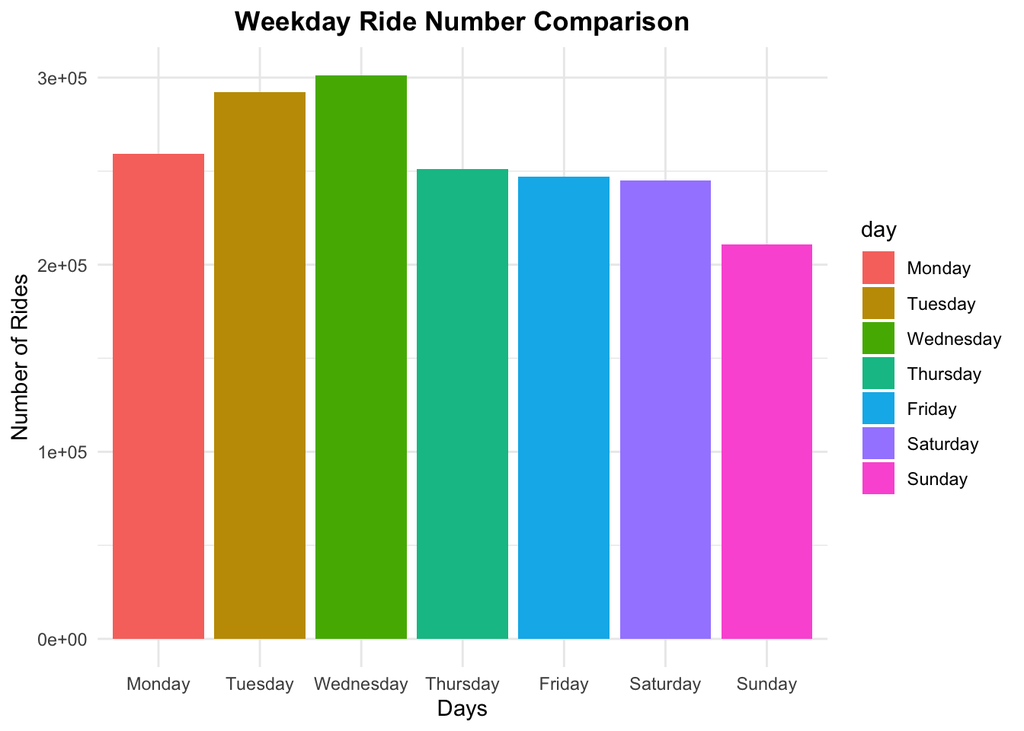

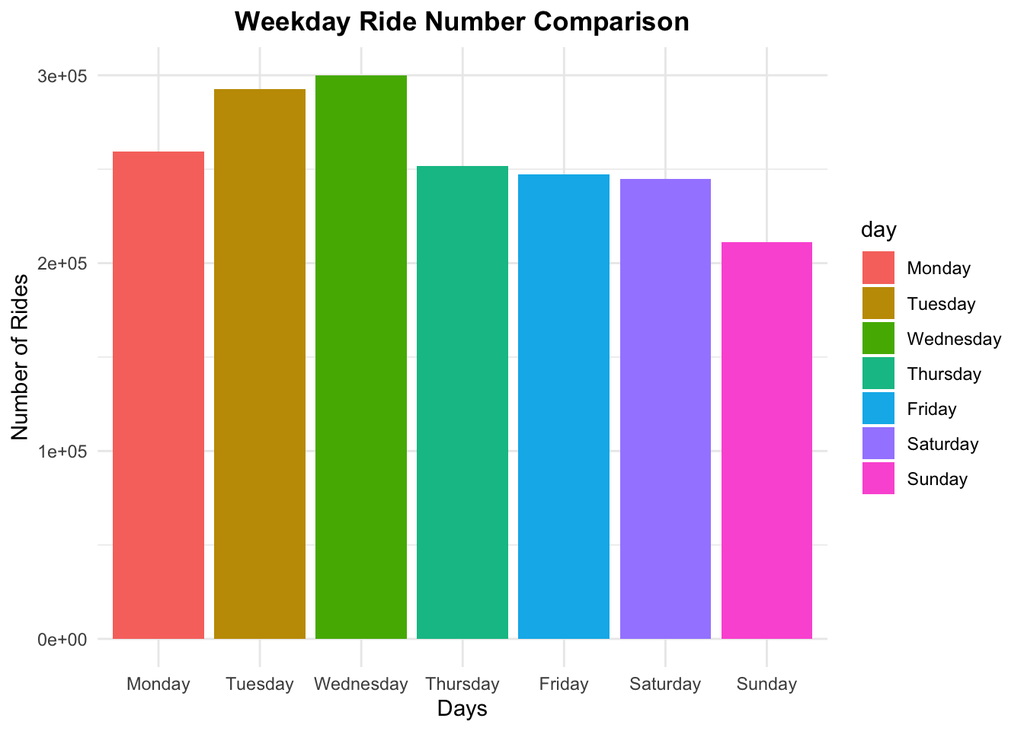

Another interesting observation is how the duration of rides might change throughout the week. Do newyorkers spend more time riding taxis on the weekend or do the majority use taxis to commute perhaps to and from work? Below we are adding the trip_duration attribute to our dataset.

```r
 split2 <- taxi_tab$tpep_pickup_datetime
 split2 <- taxi_tab$tpep_dropoff_datetime
 split2<-as.data.frame(split2)
 split2$pickup <- taxi_tab$tpep_pickup_datetime
 split2 <- split2%>%separate(split2, c("date_drop","time_drop"), sep="\\s" )
 split2 <- split2%>%separate(pickup, c("date_pickup","time_pickup"), sep="\\s" )
 split2$drop_in_mins <- 60 * 24 * as.numeric(times(split2$time_drop))
 split2$pickup_in_mins <- 60 * 24 * as.numeric(times(split2$time_pickup))
split2$trip_duration <- split2$drop_in_mins - split2$pickup_in_mins
 taxi_tab$trip_duration <- split2$trip_duration
```

Now we graph the relationship the days of the week have with the trip durations.

```r
dur_df<- taxi_tab %>%
  group_by(day) %>%
  filter(trip_duration>0) %>%
  summarise(avgdur=mean(trip_duration))

dur_df$day<- factor(dur_df$day, levels=c("Monday",
    "Tuesday", "Wednesday", "Thursday", "Friday", "Saturday","Sunday"))
dur_df<-dur_df[order(dur_df$day),]

dur_df
```

```
## # A tibble: 7 x 2
##   day       avgdur
##   <fct>      <dbl>
## 1 Monday      14.2
## 2 Tuesday     15.1
## 3 Wednesday   15.6
## 4 Thursday    16.7
## 5 Friday      16.5
## 6 Saturday    14.1
## 7 Sunday      14.1
```

```r
dur_df %>%
  ggplot(aes(x=day, y=avgdur))+geom_bar(stat = "identity")+ggtitle(label = "Weekday Trip Duration Comparison")+theme_minimal()+theme(plot.title = element_text(hjust = 0.5, lineheight = 0.8, face = "bold"))+xlab("Days")+ylab("Number of Rides")
```

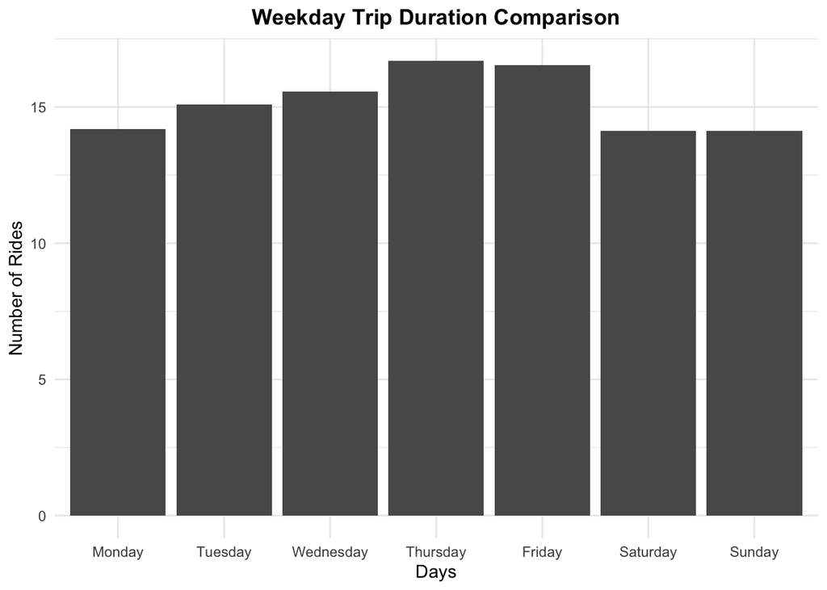

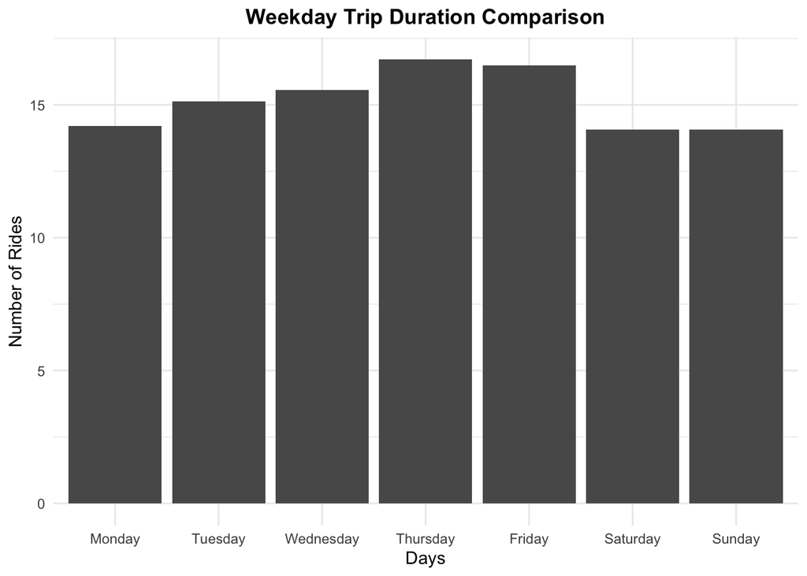

```r
dur_df
```

```
## # A tibble: 7 x 2
##   day       avgdur
##   <fct>      <dbl>
## 1 Monday      14.2
## 2 Tuesday     15.1
## 3 Wednesday   15.6
## 4 Thursday    16.7
## 5 Friday      16.5
## 6 Saturday    14.1
## 7 Sunday      14.1
```

Hypothesis testing(day of the week vs tipping):

Linear regression Model, We are trying to figure out the relationship between day of the week and the tip amount.For the linear regression model to actually be usable the mean should be very zero (or very close). In our case the mean is an extremely small value that it holds true. null hypothesis: there is no relationship between them. Alternative hypothesis, is there is a relationship between tip amount and day. If the value of the intercept <0.05 it rejects the null hypothesis. If the value of p is greater > 0.05 it does not reject the null hypothesis, meaning that there is no relationship. Even though the p-value is less than 0.05 and the mean of the residuals is close to 0. through the graph and collected data, we did not see a linear regression relationship between these two variables. So we did not feel comfortable using the Linear regression model because some of the assumptions are not met.

Pre-analysis Thought-process: Before testing the relationship between the day of the week and tipping, we thought we would write up what we thought of the relationship. We came to an agreement, saying that the tip percentage will be higher on the weekend than the weekdays. We considered the lifestyle of people in New York and believed that people are more likely to go out of their routine schedule(rather than using their daily transportation to go to work) and be willing to spend more money. In spending more money, we thought this would translate over to tipping taxi drivers. With that, we start our analysis:

Linear regression Model, We are trying to figure out the relationship between Day of the week and the Tip amount. For the linear regression model to actually be using the mean should be very zero (or very close). In our case, the mean is an extremely small value that it holds true.

Scatter plot below is showing Days of the Week vs Dist. Travelled

```r
taxi_tab$day<- factor(taxi_tab$day, levels=c("Monday",
    "Tuesday", "Wednesday", "Thursday", "Friday", "Saturday","Sunday"))
viewtaxi_tab<-taxi_tab[order(taxi_tab$day),]


taxi_tab %>% ggplot(aes(x = day, y = trip_distance))+ geom_point() + labs(title = "Day of the Week Vs Distance Travelled")
```

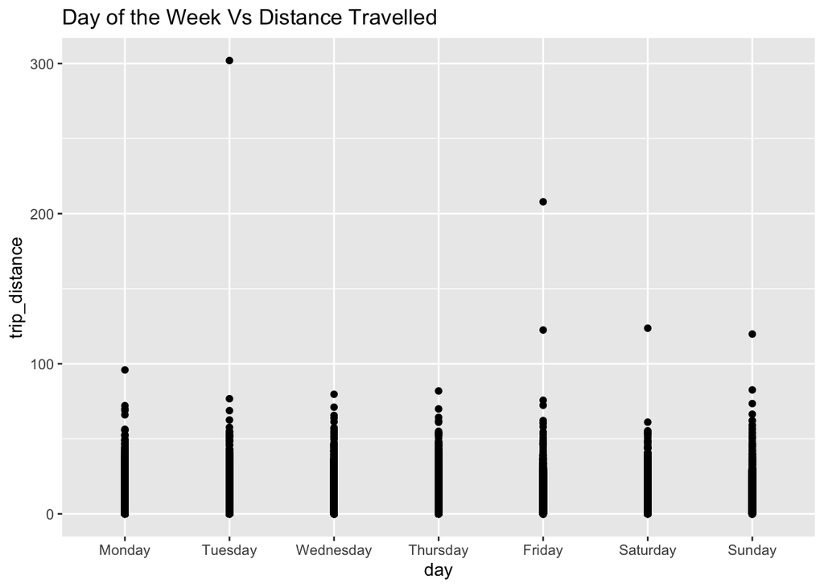

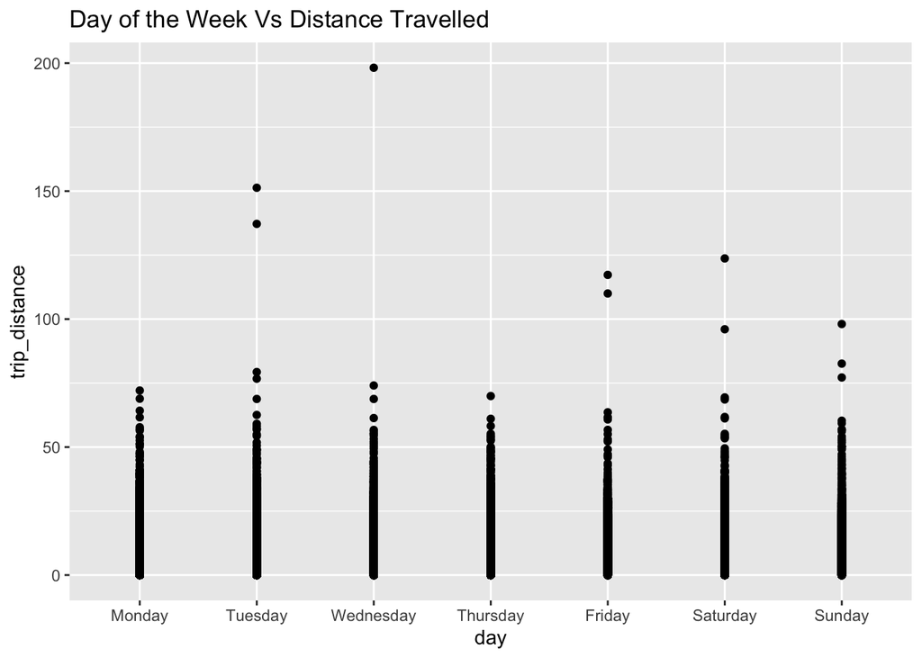

```r
    Further_testing <- taxi_tab%>% group_by(day) %>% summarize(avg_fare = mean(fare_amount), avg_tip = mean(tip_amount), sum_fare = sum(fare_amount), sum_tip = sum(tip_amount), Count = n() )
  Further_testing
```

[output not shown]

Post-Analysis: Given this information, We can safely assume that there is analytical proof that there is a relationship between the tip amount and whether it’s a weekend/weekday. We see that our pre-analysis assumptions regarding this relationship were incorrect and in fact, the opposite was true. A taxi driver is more likely to get a better tip on a weekday than a weekend.

For further information visit: “http://r-statistics.co/Assumptions-of-Linear-Regression.html”

Now we will graph the boxplot.

```r
  # box plot representing tip amounts compared to the day
  taxi_tab %>%
  filter(tip_amount>=0) %>%
  ggplot(aes(x = day, y = tip_amount))+ geom_boxplot() + geom_smooth(method = lm)+ labs(title = "Day of the Week Vs Tip amount")
```

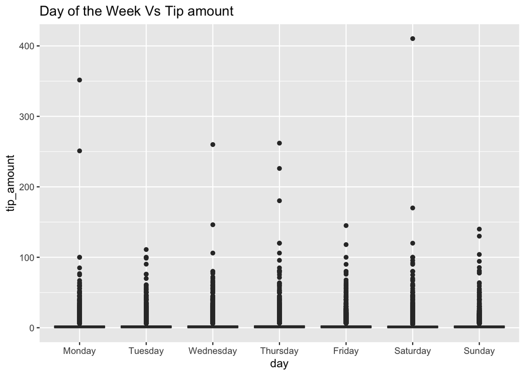

```r
  get_resid <- lm(tip_amount~day, data = taxi_tab)
  #checking the mean of the residuals
  mean(get_resid$residuals)
```

```
## [1] 1.076936e-15
```

[figure not shown]

```r
  get_resid <- lm(tip_amount~day, data = taxi_tab)
  #checking the mean of the residuals
  mean(get_resid$residuals)
```

```
## [1] 2.268914e-15
```

```r
  get_resid_tidy <- get_resid %>% tidy()

  augment_lm <- get_resid %>%augment()

  augment_lm %>% ggplot(aes(x=day, y =.resid)) +geom_violin() + geom_smooth(method = lm)+ labs(title = "Residuals vs year", x ="day", y = "residual")
```

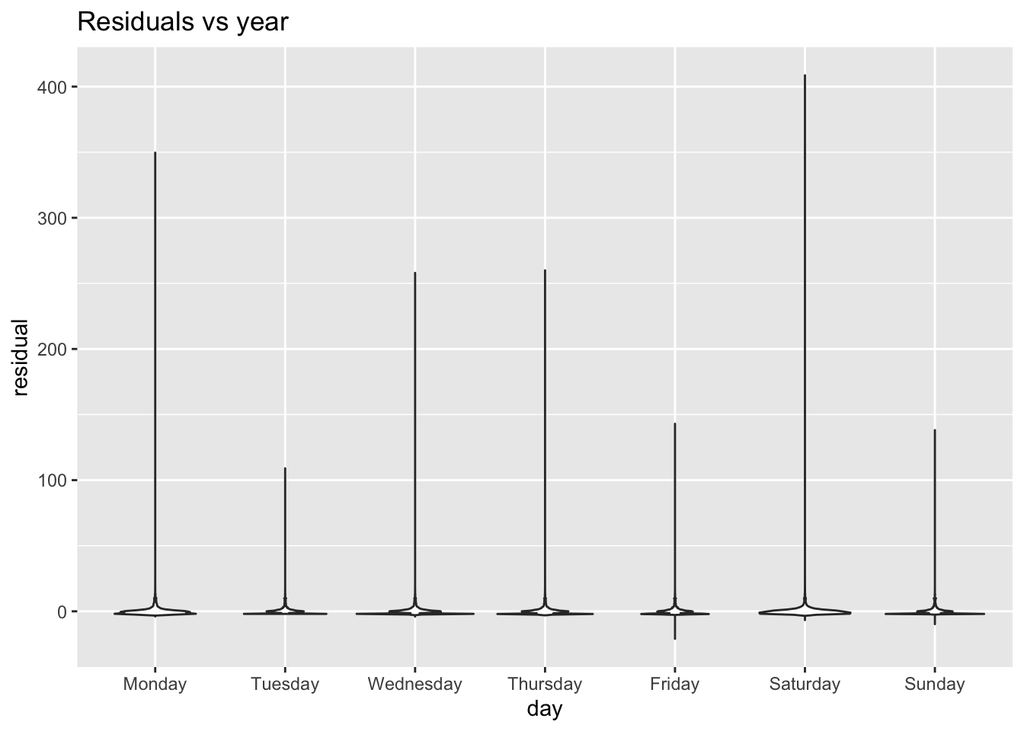

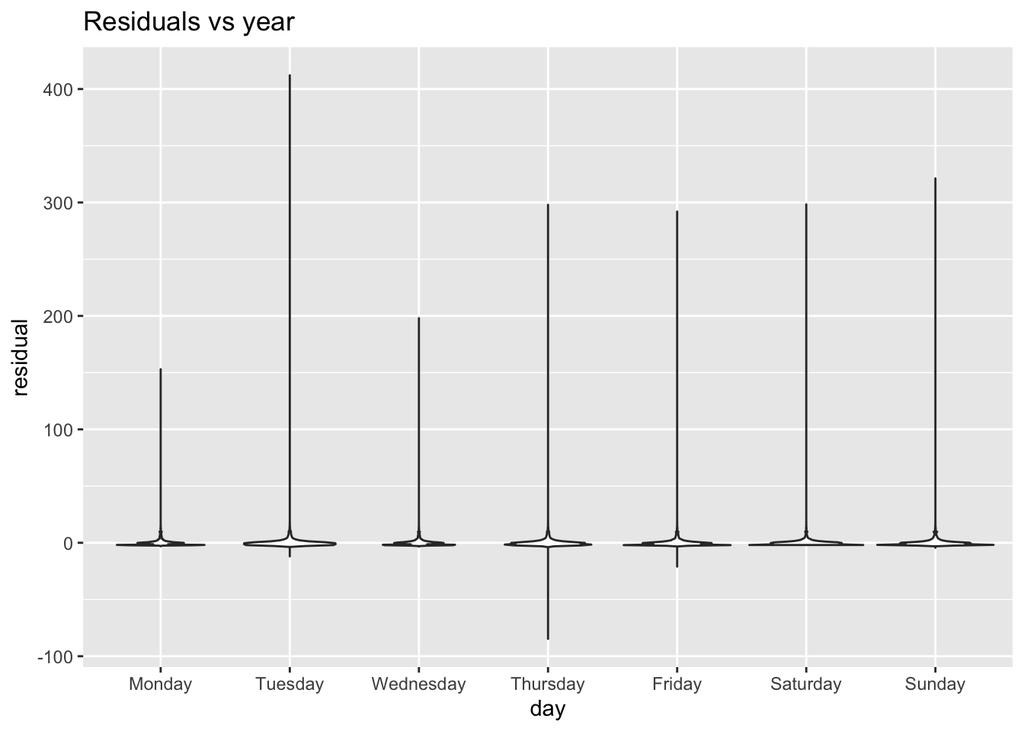

```r
  get_resid_tidy %>% knitr :: kable()
```

[output not shown]

```r
  augment_lm %>% ggplot(aes(x =factor(.fitted), y =.resid)) +geom_violin() + geom_smooth()+ labs(title = "Residuals vs fitted", x =" fitted", y = "residual")
```

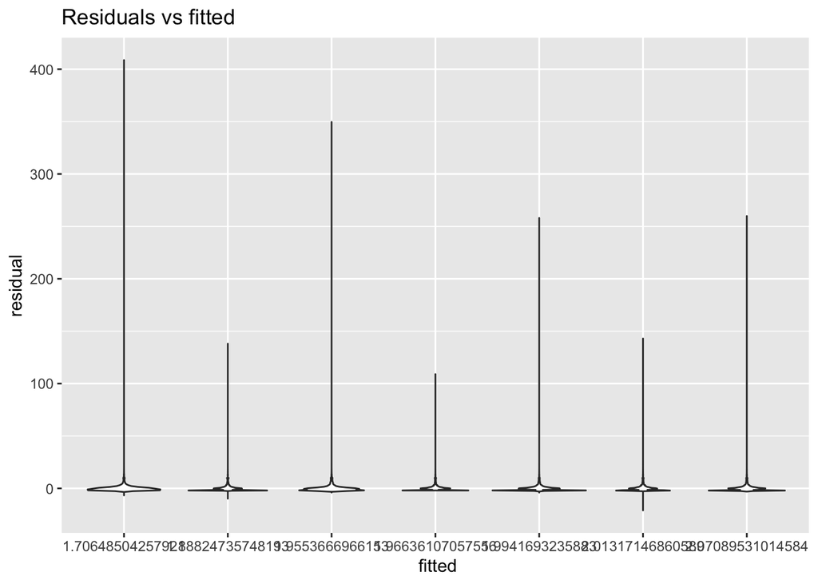

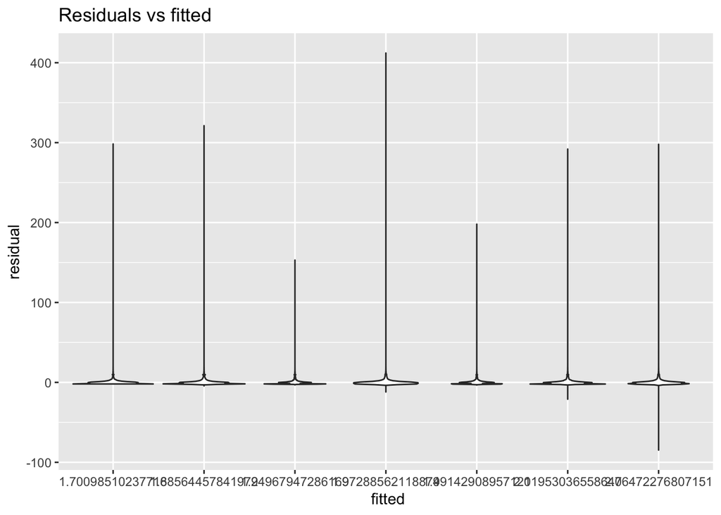

Taxi information for November of 2018. This is a secondary data set needed for our machine learning part of the project.

```r
url <- "https://s3.amazonaws.com/nyc-tlc/trip+data/yellow_tripdata_2018-11.csv"
taxi2 <- read_csv(url)
```

Before we start the prediction task analysis, we need to combine the two datasets to make a comparison between the months of October and November.

```r
taxi1 <- taxi_tab %>%
    select(tpep_pickup_datetime, tpep_dropoff_datetime, passenger_count, trip_distance, fare_amount, tip_amount, tolls_amount, PULocationID, DOLocationID)
taxi2 <- taxi2 %>%
  sample_n(2000000) %>%
    select(tpep_pickup_datetime, tpep_dropoff_datetime, passenger_count, trip_distance, fare_amount, tip_amount, tolls_amount, PULocationID, DOLocationID)

total <- rbind(taxi1, taxi2)
head(total)
```

[output not shown]

The prediction task that we are going to respond is:

Can we predict if the tip amount will increase or decrease one month from now?

We are going to use machine learning to answer this question. Even though there are many different methods of machine learning, the method that we are going to use is a random forest with 50 tress. Here is a link to explore different methods of machine learning in R: https://machinelearningmastery.com/machine-learning-in-r-step-by-step/ This website has interesting info on machine learning and explains how to use each method.

```r
   total$my <- format(as.Date(total$tpep_pickup_datetime,format="%Y-%m-%d"), format = "%m")
   total$my <- as.numeric(total$my)
   total$yy <- format(as.Date(total$tpep_pickup_datetime,format="%Y-%m-%d"), format = "%Y")
   total$yy <- as.numeric(total$yy)

   total <- mutate(total, dm = my + yy*1000)


   wp <- total %>%
   drop_na() %>%
   filter(dm  %in% c("2018010", "2018011")) %>%
   select(PULocationID, dm, tip_amount) %>%
   distinct(PULocationID, dm, .keep_all = TRUE) %>%
   spread(dm, tip_amount)
   names(wp)[names(wp) == "2018010"] <- "October"
   names(wp)[names(wp) == "2018011"] <- "November"


   wp <- mutate(wp, diff = November - October)
   wp <- mutate(wp, Direction = ifelse(diff>0, "up", "down"))
   wp <- select(wp, PULocationID, Direction)

   head(wp)
```

[output not shown]

In order to train our model, we tidy the data into a wide dataset using the tidyr::spread function, then we create a data frame that shows the differences for each day in the month of Octobor. This table will be used later in our code.

```r
taxi_tab$tpep_pickup_datetime <- as.Date(taxi_tab$tpep_pickup_datetime)
wide_df <- taxi_tab %>%
  select(  PULocationID, tpep_pickup_datetime , tip_amount) %>%
     distinct(PULocationID, tpep_pickup_datetime, .keep_all = TRUE) %>%
  tidyr::spread(tpep_pickup_datetime, tip_amount)%>%
  select(1,5:35)
wide_df[is.na(wide_df)] <- 0.00
head(wide_df)
```

[output not shown]

Now we create a matrix from the wide dataset then we inner join the new matrix with wp dataset(which gives the direction )

```r
matrix <- wide_df %>%
  as.matrix()

ab_df <- matrix%>%
  magrittr::set_colnames(NULL) %>%
  as_data_frame() %>%
  mutate(PULocationID= wide_df$PULocationID)
final_df <- ab_df %>%
  inner_join(wp %>% select(PULocationID, Direction), by="PULocationID") %>%
  mutate(Direction=factor(Direction, levels=c("down", "up")))%>%
  select(-PULocationID) %>%
  na.omit()

head(final_df)
```

[output not shown]

The pervious codes were performed to get the necessary information to the test. This is the most important part of the machine learning, which is running the test to make the prediction. We will use 10-fold cross-validation to find out how many mtry is enough to give a decent prediction. Since the data set is big, we are using 10-fold-cross validation to make the validation sets have more examples.

https://machinelearningmastery.com/machine-learning-in-r-step-by-step/

```r
set.seed(1234)

cv_partition <- createFolds(final_df$Direction,
                            k=10, returnTrain = TRUE)

fit_control <- trainControl(
  method = "cv",
  number = 10,
  index = cv_partition,
  #indexOut = cv_partition,
  summaryFunction=twoClassSummary,
  classProbs=TRUE,
  savePredictions=TRUE)


fit <- train(Direction~.,
                    data= final_df,
                    method = "rf",
                    ntree = 50,
                    trControl = fit_control,
                    metric="ROC")

fit
```

[output not shown]

```r
curve_df <-
  fit$pred %>%
    filter(mtry == 32)

curve_df %>%
  ggplot(aes(m=up,d=factor(obs, levels=c("up","down")))) +
    geom_roc() +
    coord_equal() +
    style_roc()
```

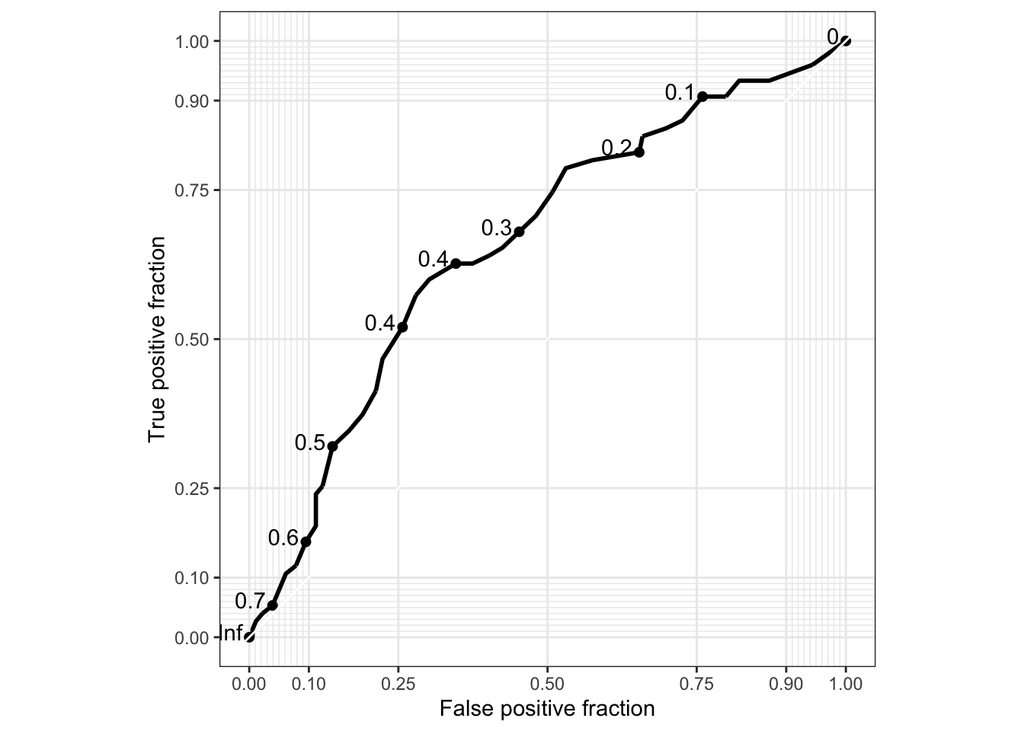

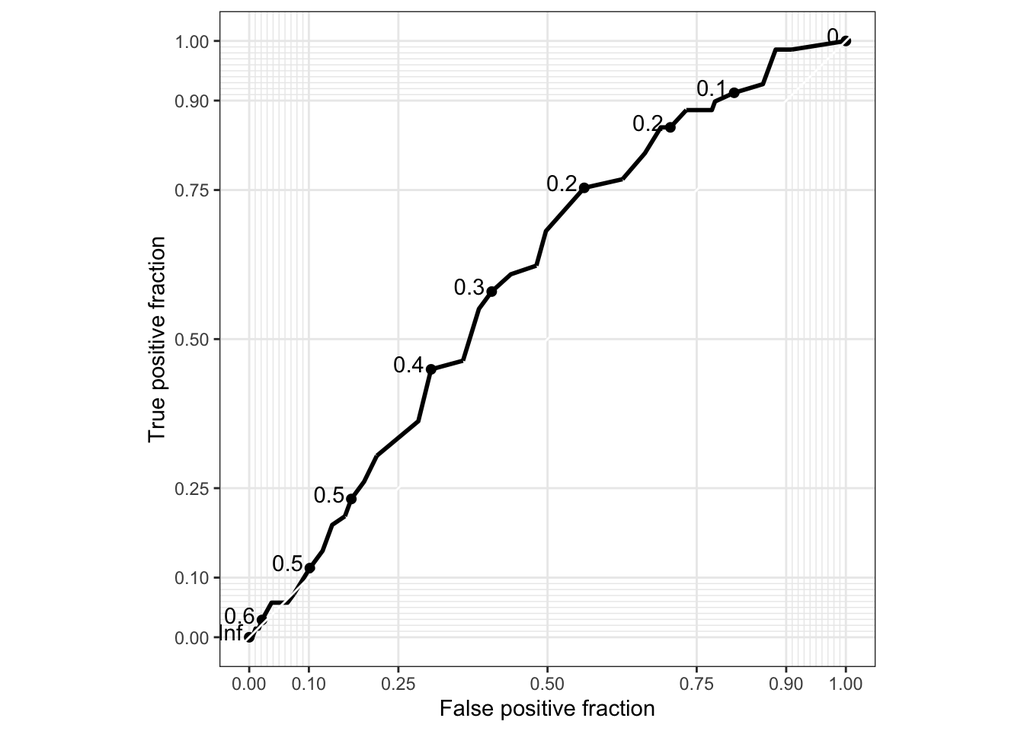

Based on the roc curve, we can see the our curve is very similar to the diagonal line in terms of shape. This indicates that our test is useless and it cannot be used to predict the tip amount of one month based on the previous month.